# Stroop Effect Statistics Project

Sunny Jiang

December 19, 2017

## Backgroud Imformation

The **Stroop effect** is a demonstration of interference in the reaction time of a task. When the name of a color (e.g. “blue”, “green”, or “red”) is printed in a color that is not denoted by the name (e.g. the word “red” printed in blue ink instead of red ink), naming the color of the word takes longer and is more prone to errors than when the color of the ink matches the name of the color.

**Congruent** words condition: the words being displayed are color words whose names match the colors in which they are printed. For example:

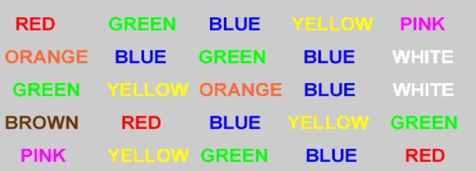

**Incongruent** words condition: the words being displayed are color words whose names **do not** match the colors in which they are printed. For example:

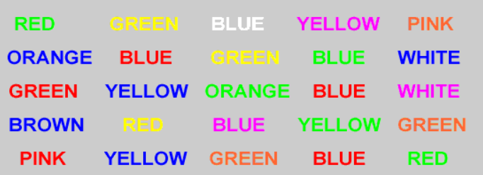

## Data Exploration

The sample size for the data we are going to use is 24. Including the time used to finishe Congruent and Incongruent tests. First explore the data by plotting histgram and density plot. We can see the average time used for Congruent test is around 13 and 21 for Incongruent test.

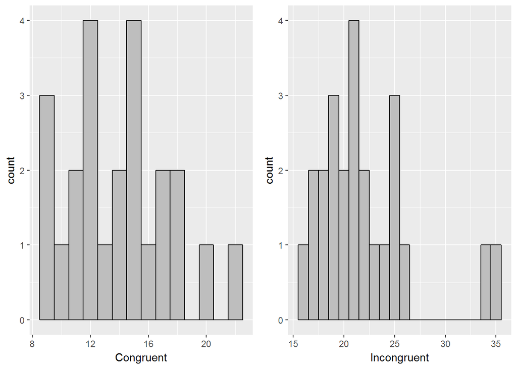

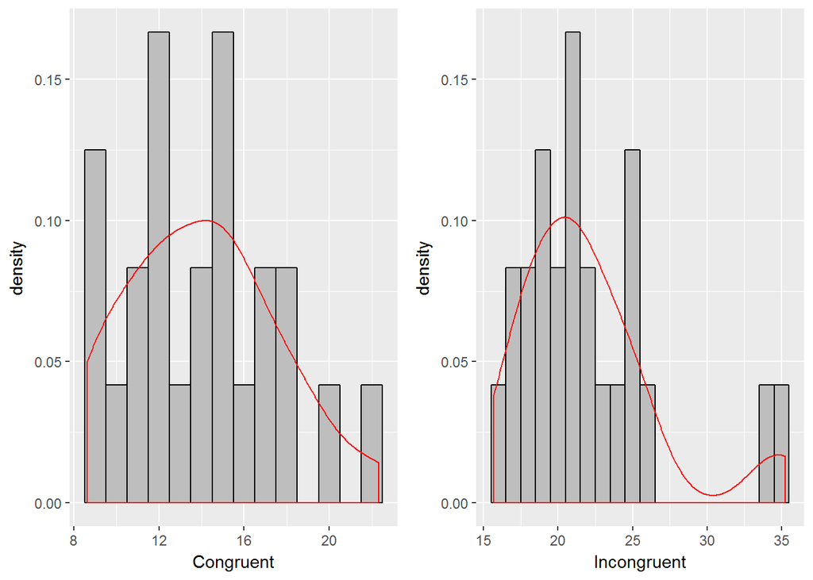

By plotting the two tests results into one plot, we can clearly see that nomally the time used in Congruent test is less.

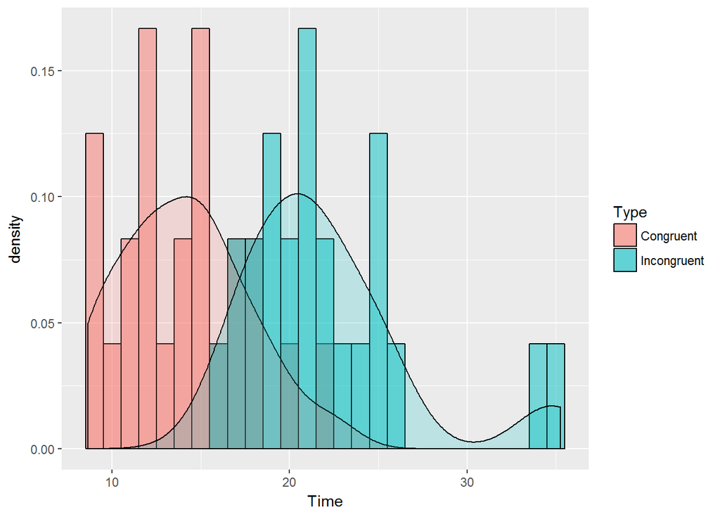

## Questions For Investigation

1. Variable
   - Independent Variable: Time used (in seconds) to finishe the test
   - Dependent Variable: Type of the test (Congruent or Incongruent)
2. Hypotheses Test: since we don’t know the mean and standard deviation of the entire population, we can’t use z-test. And the data set we have are the participants from two paired trials. So we need to use **one-tail dependent t-test in the negative direction**.
   - **Null hypothesis**: The congruent response time is greater or there is no siginificant difference in the population average amount of time it takes to state the colors of the words in a congruent or incongruent condition.
   - **Alternative hypothesis**: The congruent response time is lessin the population average amount of time it takes to state the colors of the words in a congruent or incongruent condition
3. Written in mathematical symbols
   - $H_0 : \mu_C >= \mu_I$
   - $H_A : \mu_C < \mu_I$

   or
   - $H_0 : \mu_D >= 0$
   - $H_A : \mu_D < 0$

## Hypotheses Test

First calculate the t-critical value at an alpha level of 0.05: Since sample size is 24, the degrees of freedom is 23. Look up on t-table, when alpha level is 0.05, and one-tail on the left side, the t-critical value is **-1.714**.

Then calculate sample mean, Standard Deviation and t statistic:

$$\bar{X_D} = \frac{\sum_{i=1}^{n}(X_{ci} - X_{Ii})}{n} = -7.96$$
$$S_D = \sqrt{\frac{\sum(\bar{D}-d_i)^2}{n-1}} = 4.86$$
$$t = \frac{\bar{X_D}}{S_D / \sqrt{n}} = \frac{7.96}{4.86/\sqrt{24}} = -8.02$$

Since $-8.02< -1.714$, reject $H_0$ hypotheses. The time used to finishe the Congruent test is less.

## References

https://en.wikipedia.org/wiki/Stroop_effect

https://faculty.washington.edu/chudler/java/ready.html